# Notebook: Races vs Tournament

Last updated: 03 July, 2017

# Descriptive statistics

Create list of covariates to be used in regression model.

```r
dat <- within(races, {
    year <- as.numeric(format(member_date, "%Y"))
    hours <- week1 + week2 + week3 + week4
    rating <- mm_rating
    maxrating <- mm_rating_max
    minrating <- mm_rating_min
    submissions <- mm_events
    avecodesub <- ave_nsub_past
    registrations <- mm_reg
    # svydate <- as.numeric(format(as.Date(startdate),'%d')) - 1
    lpaid <- log(paid)
    male <- gender == "Male"
    grad <- educ == "Doctorate/PhD" | educ == "Postgraduate/Master of arts"
    below30 <- age == "<20 years old" | age == "20-25 years old" |
        age == "26-30 years"
})

covars <- with(dat, data.frame(year, rating, volatility, maxrating,
    minrating, registrations, submissions, avecodesub, lpaid,
    nwins, ntop5, ntop10, risk, hours, male, timezone, grad,
    below30))
```

Check covariates are balanced across treatment groups.

```r
# FUNC to compute descriptive statistics
descriptives <- function(dat, treat = races$treatment) {
    balance.test <- function(x) {
        l <- split(x, treat)
        kruskal.test(l)$p.val
    }
    mu <- sapply(dat, mean, na.rm = TRUE)
    q50 <- sapply(dat, median, na.rm = TRUE)
    lo <- sapply(dat, min, na.rm = TRUE)
    hi <- sapply(dat, max, na.rm = TRUE)
    std <- sapply(dat, sd, na.rm = TRUE)
    pval <- sapply(dat, balance.test)
    n <- sapply(dat, function(x) sum(!is.na(x)))
    tab <- cbind(mu, q50, std, lo, hi, n, pval)
    colnames(tab) <- c("Mean", "Median", "St.Dev.", "Min", "Max",
        "Obs.", "P-value")
    return(tab)
}

tab <- descriptives(covars)
signif(tab, 2)
```

```
##                  Mean Median St.Dev.    Min  Max Obs. P-value
## year          2000.00 2000.0    3.50 2000.0 2000  300    0.60
## rating        1300.00 1300.0  420.00  590.0 3100  200    0.99
## volatility     340.00  350.0   90.00  150.0  590  210    0.98
## maxrating     1400.00 1400.0  420.00  610.0 3100  210    0.59
## minrating     1100.00 1100.0  300.00  570.0 1900  210    0.71
## registrations   18.00    9.0   23.00    1.0  160  300    0.63
## submissions      7.20    2.0   12.00    0.0   91  300    0.87
## avecodesub       6.70    5.0    6.20    0.0   52  210    0.99
## lpaid            8.40    8.4    2.50    3.2   14  140    0.79
## nwins            0.28    0.0    1.80    0.0   27  300    0.37
## ntop5            0.93    0.0    4.20    0.0   56  300    0.57
## ntop10           1.60    0.0    5.40    0.0   64  300    0.27
## risk             6.40    7.0    2.20    1.0   10  280    0.96
## hours           31.00   24.0   25.00    0.0  190  280    1.00
## male             0.95    1.0    0.21    0.0    1  280    0.38
## timezone         2.10    2.0    5.10   -8.0   10  280    0.39
## grad             0.47    0.0    0.50    0.0    1  280    0.21
## below30          0.66    1.0    0.47    0.0    1  280    0.51
```

```r
# xtab <- xtable(tab) digits(xtab) <- c(1, 1, rep(0,
# ncol(tab)-2), 3) align(xtab) <- c('@{}l', rep('r',
# ncol(tab))) caption(xtab) <- 'Descriptive statistics'
# label(xtab) <- 'summary' render.xtable(xtab)
```

Show skill rating distribution is the same across rooms

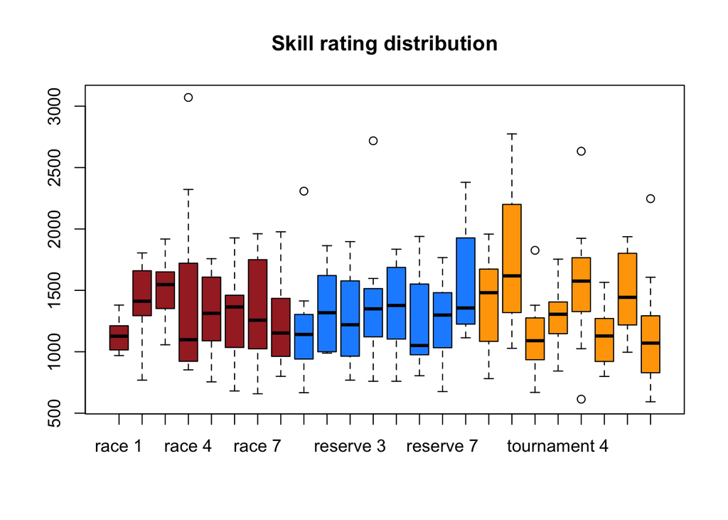

```r
colors <- c("brown", "dodgerblue", "orange")
boxplot(mm_rating ~ paste(treatment, room), data = races, col = rep(colors,
    each = 8))
title("Skill rating distribution")
```

# Entry

Differences in room entrants between different competition styles and between large and small rooms.

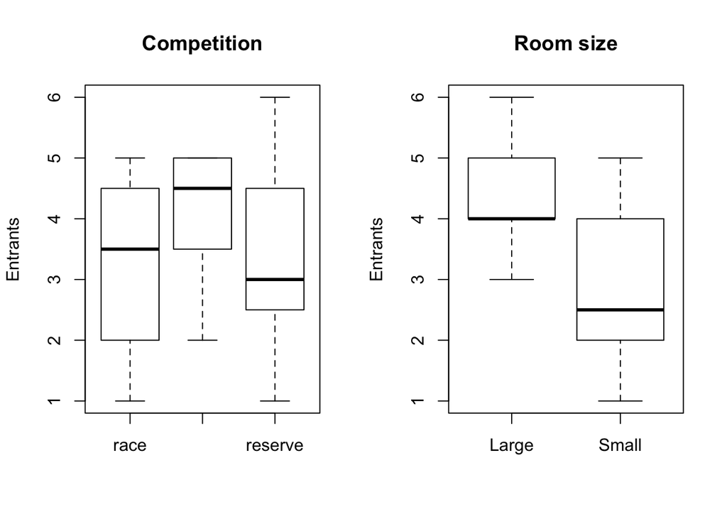

```r
counts <- aggregate(submit ~ room + room_size + treatment, data = races,
    sum)

par(mfrow = c(1, 2))
boxplot(submit ~ treatment, data = counts, ylab = "Entrants")
title("Competition")
boxplot(submit ~ room_size, data = counts, ylab = "Entrants")
title("Room size")
```

Testing differences between threshold (race & reserve) and tournament. Bootstrap

```r
# Competition tournament
wilcox.test(submit ~ treatment == "tournament", data = counts,
    alternative = "less", exact = FALSE, correct = FALSE)  # p=0.08
```

```
##
##  Wilcoxon rank sum test
##
## data:  submit by treatment == "tournament"
## W = 42.5, p-value = 0.08877
## alternative hypothesis: true location shift is less than 0
```

```r
# Bootstrap ...

# Room size
wilcox.test(submit ~ room_size, data = counts, exact = FALSE,
    correct = FALSE)  # p=0.01
```

```
##
##  Wilcoxon rank sum test
##
## data:  submit by room_size
## W = 114, p-value = 0.01302
## alternative hypothesis: true location shift is not equal to 0
```

```r
# Submit and room size
tab.size <- with(races, table(submit, room_size))
fisher.test(tab.size)  # p = 0.98
```

```
##
##  Fisher's Exact Test for Count Data
##
## data:  tab.size
## p-value = 1
## alternative hypothesis: true odds ratio is not equal to 1
## 95 percent confidence interval:
##  0.5689643 1.6912635
## sample estimates:
## odds ratio
##  0.9846648
```

```r
# Submit and competition styles
tab <- with(races, table(submit, treatment))
fisher.test(tab)  # p = 0.52
```

```
##
##  Fisher's Exact Test for Count Data
##
## data:  tab
## p-value = 0.5255
## alternative hypothesis: two.sided
```

```r
# Competition styles with target
tab <- with(races, table(submit, treatment == "tournament"))
fisher.test(tab, alternative = "greater")  # p=0.15
```

```
##
##  Fisher's Exact Test for Count Data
##
## data:  tab
## p-value = 0.1558
## alternative hypothesis: true odds ratio is greater than 1
## 95 percent confidence interval:
##  0.8435475       Inf
## sample estimates:
## odds ratio
##   1.355339
```

If we assume uniform priors, we can easily compute the posteriors in each treatment. (Not sure what we can do with this result.)

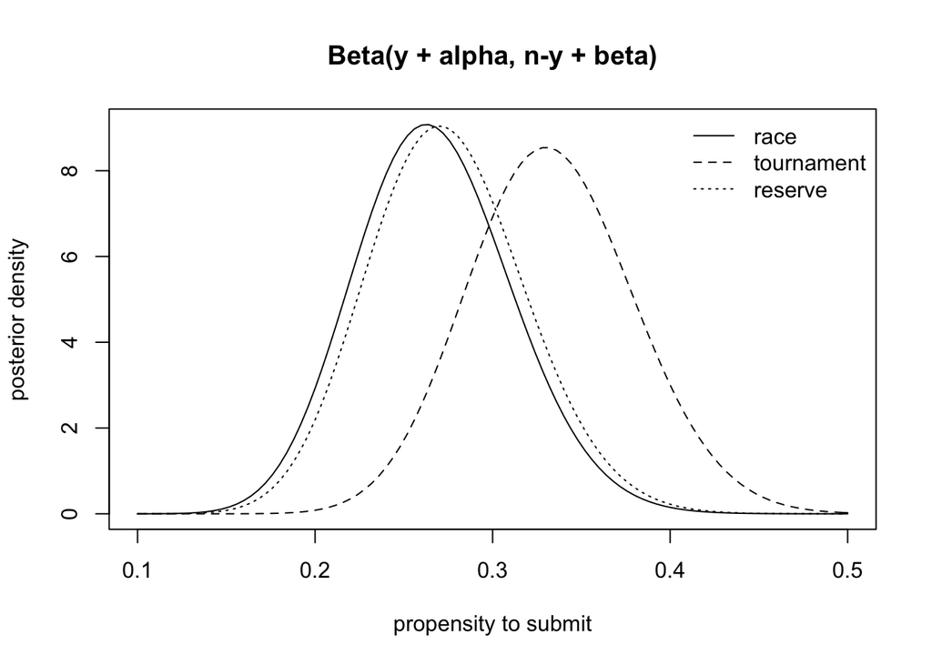

```r
# Bayesian analysis Compute posteriors Beta(1 + success, 1 +
# n - success)
plot.posterior <- function(x, ...) {
    tab <- with(races, table(submit, treatment))
    param <- data.frame(tab + 1)
    index <- param$treatment == x
    shape <- param[index, ]
    curve(dbeta(x, shape$Freq[2], shape$Freq[1]), ...)
}

# PLOTs
plot.posterior("race", from = 0.1, to = 0.5, xlab = "propensity to submit",
    ylab = "posterior density")
plot.posterior("tournament", add = TRUE, lty = 2)
plot.posterior("reserve", add = TRUE, lty = 3)
title("Beta(y + alpha, n-y + beta)")
legend("topright", legend = levels(races$treatment), lty = 1:3,
    bty = "n")
```

# Regression analysis of entry

Impute missing values at random for the survey. Ignore missing ratings (or impute them).

```r
dat.imp <- within(dat, {
    set.seed(25978)
    rating.100 <- rating/100
    rated <- !is.na(rating)
    rating.100imp <- impute(rating/100, "zero")
    hours.imp <- impute(hours, "random")
    risk.imp <- impute(risk, "random")
    grad.imp <- impute(grad, "random")
    male.imp <- impute(male, "random")
    below30.imp <- impute(below30, "random")
    timezone.imp <- impute(timezone, "random")
    expert <- cut(submissions, quantile(submissions[!is.na(rating)]),
        include = TRUE)
})
```

Fitting the model

```r
# First model has no covariates (i.e., $\gamma=0$)
summary(m0 <- glm(submit ~ treatment, binomial(logit), data = dat.imp))
```

```
##
## Call:
## glm(formula = submit ~ treatment, family = binomial(logit), data = dat.imp)
##
## Deviance Residuals:
##     Min       1Q   Median       3Q      Max
## -0.8950  -0.7934  -0.7806   1.4891   1.6353
##
## Coefficients:
##                     Estimate Std. Error z value Pr(>|z|)
## (Intercept)         -1.03236    0.22839  -4.520 6.18e-06 ***
## treatmenttournament  0.32418    0.31207   1.039    0.299
## treatmentreserve     0.03774    0.32077   0.118    0.906
## ---
## Signif. codes:  0 '***' 0.001 '**' 0.01 '*' 0.05 '.' 0.1 ' ' 1
##
## (Dispersion parameter for binomial family taken to be 1)
##
##     Null deviance: 358.81  on 298  degrees of freedom
## Residual deviance: 357.49  on 296  degrees of freedom
## AIC: 363.49
##
## Number of Fisher Scoring iterations: 4
```

```r
# The second model adds the main skill rating measure which
# is available for 2/3 of our population. It seemed better to
# rescale rating in 100-point units and center it on the
# median value. Thus, the estimate of the intercept can be
# easily transformed in the probability of participation of
# the median rated individual assigned to a room with a race
# competition style.

summary(m1 <- update(m0, " ~ . + rating.100"))
```

```
##
## Call:
## glm(formula = submit ~ treatment + rating.100, family = binomial(logit),
##     data = dat.imp)
##
## Deviance Residuals:
##     Min       1Q   Median       3Q      Max
## -1.5846  -0.9441  -0.7840   1.2855   1.8284
##
## Coefficients:
##                     Estimate Std. Error z value Pr(>|z|)
## (Intercept)         -2.15239    0.55935  -3.848 0.000119 ***
## treatmenttournament  0.31570    0.36635   0.862 0.388824
## treatmentreserve     0.20445    0.36931   0.554 0.579855
## rating.100           0.10470    0.03597   2.911 0.003607 **
## ---
## Signif. codes:  0 '***' 0.001 '**' 0.01 '*' 0.05 '.' 0.1 ' ' 1
##
## (Dispersion parameter for binomial family taken to be 1)
##
##     Null deviance: 268.13  on 204  degrees of freedom
## Residual deviance: 258.38  on 201  degrees of freedom
##   (94 observations deleted due to missingness)
## AIC: 266.38
##
## Number of Fisher Scoring iterations: 4
```

```r
summary(m1bis <- update(m0, " ~ . + rating.100imp + rated"))
```

```
##
## Call:
## glm(formula = submit ~ treatment + rating.100imp + rated, family = binomial(logit),
##     data = dat.imp)
##
## Deviance Residuals:
##     Min       1Q   Median       3Q      Max
## -1.6221  -0.8616  -0.5772   1.1410   2.0908
##
## Coefficients:
##                     Estimate Std. Error z value Pr(>|z|)
## (Intercept)         -2.06658    0.37048  -5.578 2.43e-08 ***
## treatmenttournament  0.35855    0.32793   1.093  0.27422
## treatmentreserve     0.05025    0.33595   0.150  0.88109
## rating.100imp        0.10503    0.03603   2.915  0.00356 **
## ratedTRUE           -0.05415    0.59653  -0.091  0.92767
## ---
## Signif. codes:  0 '***' 0.001 '**' 0.01 '*' 0.05 '.' 0.1 ' ' 1
##
## (Dispersion parameter for binomial family taken to be 1)
##
##     Null deviance: 358.81  on 298  degrees of freedom
## Residual deviance: 329.52  on 294  degrees of freedom
## AIC: 339.52
##
## Number of Fisher Scoring iterations: 4
```

```r
# The third column adds time availability (hours)
summary(m2 <- update(m1bis, " ~ . + hours.imp"))
```

```
##
## Call:
## glm(formula = submit ~ treatment + rating.100imp + rated + hours.imp,
##     family = binomial(logit), data = dat.imp)
##
## Deviance Residuals:
##     Min       1Q   Median       3Q      Max
## -1.7025  -0.8386  -0.5452   1.0772   2.2426
##
## Coefficients:
##                      Estimate Std. Error z value Pr(>|z|)
## (Intercept)         -2.637258   0.441302  -5.976 2.29e-09 ***
## treatmenttournament  0.335406   0.334323   1.003  0.31574
## treatmentreserve     0.087300   0.339806   0.257  0.79725
## rating.100imp        0.110261   0.036512   3.020  0.00253 **
## ratedTRUE           -0.018586   0.606103  -0.031  0.97554
## hours.imp            0.014977   0.005321   2.815  0.00488 **
## ---
## Signif. codes:  0 '***' 0.001 '**' 0.01 '*' 0.05 '.' 0.1 ' ' 1
##
## (Dispersion parameter for binomial family taken to be 1)
##
##     Null deviance: 358.81  on 298  degrees of freedom
## Residual deviance: 320.88  on 293  degrees of freedom
## AIC: 332.88
##
## Number of Fisher Scoring iterations: 4
```

```r
# ... add demographics to m2
summary(m3 <- update(m2, " ~ . + timezone.imp + grad.imp + below30.imp + male.imp"))
```

```
##
## Call:
## glm(formula = submit ~ treatment + rating.100imp + rated + hours.imp +
##     timezone.imp + grad.imp + below30.imp + male.imp, family = binomial(logit),
##     data = dat.imp)
##
## Deviance Residuals:
##     Min       1Q   Median       3Q      Max
## -1.8053  -0.8455  -0.5458   1.0699   2.4022
##
## Coefficients:
##                      Estimate Std. Error z value Pr(>|z|)
## (Intercept)         -2.218245   0.904016  -2.454  0.01414 *
## treatmenttournament  0.347162   0.337793   1.028  0.30407
## treatmentreserve     0.109187   0.347105   0.315  0.75309
## rating.100imp        0.118425   0.039143   3.025  0.00248 **
## ratedTRUE           -0.134396   0.627667  -0.214  0.83045
## hours.imp            0.015720   0.005371   2.927  0.00342 **
## timezone.imp        -0.001356   0.027652  -0.049  0.96088
## grad.impTRUE        -0.398056   0.297410  -1.338  0.18076
## below30.impTRUE     -0.504968   0.294621  -1.714  0.08654 .
## male.impTRUE         0.069384   0.829711   0.084  0.93336
## ---
## Signif. codes:  0 '***' 0.001 '**' 0.01 '*' 0.05 '.' 0.1 ' ' 1
##
## (Dispersion parameter for binomial family taken to be 1)
##
##     Null deviance: 358.81  on 298  degrees of freedom
## Residual deviance: 316.68  on 289  degrees of freedom
## AIC: 336.68
##
## Number of Fisher Scoring iterations: 4
```

```r
# ... add risk aversion
summary(m4 <- update(m2, " ~ . + risk.imp"))
```

```
##
## Call:
## glm(formula = submit ~ treatment + rating.100imp + rated + hours.imp +
##     risk.imp, family = binomial(logit), data = dat.imp)
##
## Deviance Residuals:
##     Min       1Q   Median       3Q      Max
## -1.7211  -0.8512  -0.5473   1.0615   2.2535
##
## Coefficients:
##                      Estimate Std. Error z value Pr(>|z|)
## (Intercept)         -2.356060   0.581721  -4.050 5.12e-05 ***
## treatmenttournament  0.347033   0.335464   1.034  0.30091
## treatmentreserve     0.108517   0.341497   0.318  0.75066
## rating.100imp        0.105381   0.037022   2.846  0.00442 **
## ratedTRUE            0.018806   0.608463   0.031  0.97534
## hours.imp            0.015549   0.005465   2.845  0.00444 **
## risk.imp            -0.045815   0.062397  -0.734  0.46280
## ---
## Signif. codes:  0 '***' 0.001 '**' 0.01 '*' 0.05 '.' 0.1 ' ' 1
##
## (Dispersion parameter for binomial family taken to be 1)
##
##     Null deviance: 358.81  on 298  degrees of freedom
## Residual deviance: 320.34  on 292  degrees of freedom
## AIC: 334.34
##
## Number of Fisher Scoring iterations: 4
```

```r
# ... add everything stepwise regression
summary(m5 <- step(update(m3, " ~ . + risk.imp")))
```

```
## Start:  AIC=338.02
## submit ~ treatment + rating.100imp + rated + hours.imp + timezone.imp +
##     grad.imp + below30.imp + male.imp + risk.imp
##
##                 Df Deviance    AIC
## - treatment      2   317.19 335.19
## - timezone.imp   1   316.02 336.02
## - male.imp       1   316.02 336.02
## - rated          1   316.04 336.04
## - risk.imp       1   316.68 336.68
## <none>               316.02 338.02
## - grad.imp       1   318.03 338.03
## - below30.imp    1   318.93 338.93
## - rating.100imp  1   324.98 344.98
## - hours.imp      1   325.85 345.85
##
## Step:  AIC=335.19
## submit ~ rating.100imp + rated + hours.imp + timezone.imp + grad.imp +
##     below30.imp + male.imp + risk.imp
##
##                 Df Deviance    AIC
## - male.imp       1   317.19 333.19
## - timezone.imp   1   317.19 333.19
## - rated          1   317.20 333.20
## - risk.imp       1   317.80 333.80
## - grad.imp       1   319.08 335.08
## <none>               317.19 335.19
## - below30.imp    1   320.16 336.16
## - rating.100imp  1   325.96 341.96
## - hours.imp      1   327.31 343.31
##
## Step:  AIC=333.19
## submit ~ rating.100imp + rated + hours.imp + timezone.imp + grad.imp +
##     below30.imp + risk.imp
##
##                 Df Deviance    AIC
## - timezone.imp   1   317.19 331.19
## - rated          1   317.20 331.20
## - risk.imp       1   317.80 331.80
## - grad.imp       1   319.12 333.12
```

[output cut: 33 more lines]

```
##                 Df Deviance    AIC
## - grad.imp       1   319.56 327.56
## <none>               317.85 327.85
## - below30.imp    1   320.89 328.89
## - hours.imp      1   327.64 335.64
## - rating.100imp  1   345.25 353.25
##
## Step:  AIC=327.56
## submit ~ rating.100imp + hours.imp + below30.imp
##
##                 Df Deviance    AIC
## <none>               319.56 327.56
## - below30.imp    1   321.98 327.98
## - hours.imp      1   329.14 335.14
## - rating.100imp  1   345.26 351.26
```

```
##
## Call:
## glm(formula = submit ~ rating.100imp + hours.imp + below30.imp,
##     family = binomial(logit), data = dat.imp)
##
## Deviance Residuals:
##     Min       1Q   Median       3Q      Max
## -1.6977  -0.8349  -0.5359   1.1203   2.2702
##
## Coefficients:
##                  Estimate Std. Error z value Pr(>|z|)
## (Intercept)     -2.177883   0.395781  -5.503 3.74e-08 ***
## rating.100imp    0.103278   0.021788   4.740 2.14e-06 ***
## hours.imp        0.015741   0.005331   2.953  0.00315 **
## below30.impTRUE -0.445783   0.285519  -1.561  0.11845
## ---
## Signif. codes:  0 '***' 0.001 '**' 0.01 '*' 0.05 '.' 0.1 ' ' 1
##
## (Dispersion parameter for binomial family taken to be 1)
##
##     Null deviance: 358.81  on 298  degrees of freedom
## Residual deviance: 319.56  on 295  degrees of freedom
## AIC: 327.56
##
## Number of Fisher Scoring iterations: 4
```

```r
# Compare models
models <- list(m0, m1, m1bis, m2, m3, m4, m5)
stargazer(models, type = "text", digits = 2)
```

```
##
## =================================================================================
##                                          Dependent variable:
##                     -------------------------------------------------------------
##                                                submit
##                       (1)      (2)      (3)      (4)      (5)     (6)      (7)
## ---------------------------------------------------------------------------------
## treatmenttournament   0.32     0.32     0.36     0.34    0.35     0.35
##                      (0.31)   (0.37)   (0.33)   (0.33)  (0.34)   (0.34)
##
## treatmentreserve      0.04     0.20     0.05     0.09    0.11     0.11
##                      (0.32)   (0.37)   (0.34)   (0.34)  (0.35)   (0.34)
##
## rating.100                   0.10***
##                               (0.04)
##
## rating.100imp                         0.11***  0.11***  0.12*** 0.11***  0.10***
##                                        (0.04)   (0.04)  (0.04)   (0.04)   (0.02)
##
## rated                                  -0.05    -0.02    -0.13    0.02
##                                        (0.60)   (0.61)  (0.63)   (0.61)
##
## hours.imp                                      0.01***  0.02*** 0.02***  0.02***
##                                                 (0.01)  (0.01)   (0.01)   (0.01)
##
## timezone.imp                                            -0.001
##                                                         (0.03)
##
## grad.imp                                                 -0.40
##                                                         (0.30)
##
## below30.imp                                             -0.50*            -0.45
##                                                         (0.29)            (0.29)
##
## male.imp                                                 0.07
##                                                         (0.83)
##
## risk.imp                                                         -0.05
##                                                                  (0.06)
##
## Constant            -1.03*** -2.15*** -2.07*** -2.64*** -2.22** -2.36*** -2.18***
##                      (0.23)   (0.56)   (0.37)   (0.44)  (0.90)   (0.58)   (0.40)
##
## ---------------------------------------------------------------------------------
## Observations          299      205      299      299      299     299      299
## Log Likelihood      -178.75  -129.19  -164.76  -160.44  -158.34 -160.17  -159.78
## Akaike Inf. Crit.    363.49   266.38   339.52   332.88  336.68   334.34   327.56
## =================================================================================
## Note:                                                 *p<0.1; **p<0.05; ***p<0.01
```

Explore accuracy of predictions of the stepwise model

```r
# Compare models in terms of prediction accuracy
accuracy <- function(fit) {
    yhat <- predict(fit, type = "response")
    tab <- table(predicted = ifelse(yhat > 0.5, 1, 0), actual = fit$y)
    tp <- tab[2, 2]
    fp <- tab[2, 1]
    fn <- tab[1, 2]
    precision <- tp/(tp + fp)
    recall <- tp/(tp + fn)
    fmeasure <- 2 * precision * recall/(precision + recall)
    list(conf.table = tab, precision = precision, recall = recall,
        f.measure = fmeasure)
}
accuracy(m5)
```

```
## $conf.table
##          actual
## predicted   0   1
##         0 199  70
##         1  14  16
##
## $precision
## [1] 0.5333333
##
## $recall
## [1] 0.1860465
##
## $f.measure
## [1] 0.2758621
```

```
##   [,1]        [,2]        [,3]        [,4]        [,5]        [,6]
## x Numeric,101 Numeric,101 Numeric,101 Numeric,101 Numeric,101 Numeric,101
## y Numeric,101 Numeric,101 Numeric,101 Numeric,101 Numeric,101 Numeric,101
##   [,7]
## x Numeric,101
## y Numeric,101
```

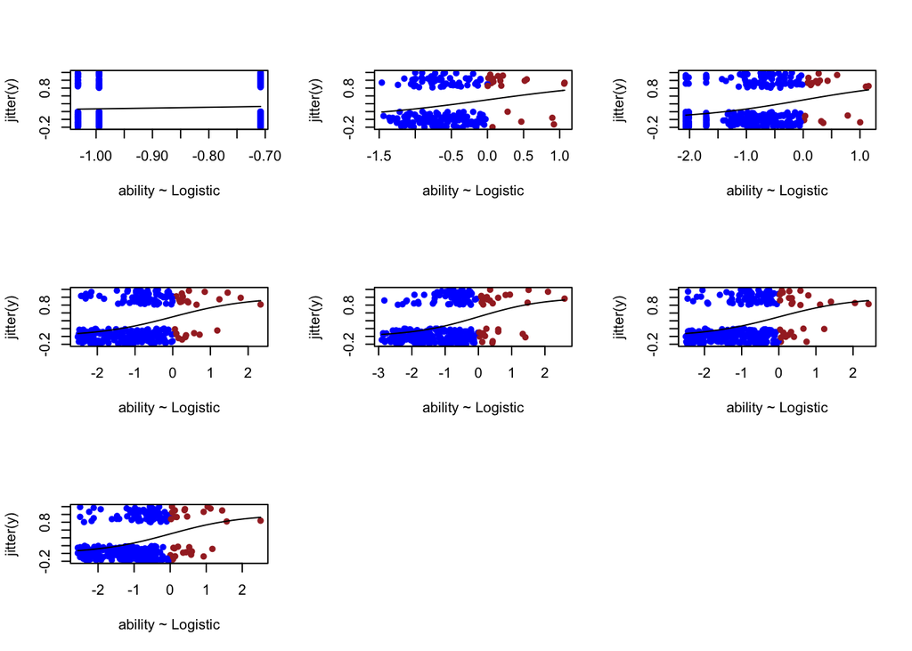

```r
summarize.fit <- function(x) {
    yhat <- predict(x)
    with(x, plot(jitter(y) ~ yhat, col = ifelse(yhat > 0, "brown",
        "blue"), pch = 16, xlab = "ability ~ Logistic"))
    curve(ilogit, add = T)
}
par(mfrow = c(3, 3))
sapply(models, summarize.fit)
```

Study interaction effecs first with models on a subset and then using interaction terms in the regression.

```r
# Using Akaike criterion to select the best model, we now
# compute the model for each treatment alone
summary(race <- update(m5, "~ . -treatment", subset = treatment ==
    "race"))
```

```
##
## Call:
## glm(formula = submit ~ rating.100imp + hours.imp + below30.imp,
##     family = binomial(logit), data = dat.imp, subset = treatment ==
##         "race")
##
## Deviance Residuals:
##     Min       1Q   Median       3Q      Max
## -1.7541  -0.7350  -0.4984   0.6929   2.3167
##
## Coefficients:
##                  Estimate Std. Error z value Pr(>|z|)
## (Intercept)     -2.917029   0.802160  -3.636 0.000276 ***
## rating.100imp    0.110798   0.041102   2.696 0.007024 **
## hours.imp        0.023578   0.009764   2.415 0.015738 *
## below30.impTRUE -0.049369   0.530670  -0.093 0.925879
## ---
## Signif. codes:  0 '***' 0.001 '**' 0.01 '*' 0.05 '.' 0.1 ' ' 1
##
## (Dispersion parameter for binomial family taken to be 1)
##
##     Null deviance: 114.006  on 98  degrees of freedom
## Residual deviance:  99.648  on 95  degrees of freedom
## AIC: 107.65
##
## Number of Fisher Scoring iterations: 4
```

```r
summary(tour <- update(m5, "~ . -treatment", subset = treatment ==
    "tournament"))
```

```
##
## Call:
## glm(formula = submit ~ rating.100imp + hours.imp + below30.imp,
##     family = binomial(logit), data = dat.imp, subset = treatment ==
##         "tournament")
##
## Deviance Residuals:
##     Min       1Q   Median       3Q      Max
## -1.8194  -0.8914  -0.5576   1.0742   2.2574
##
## Coefficients:
##                  Estimate Std. Error z value Pr(>|z|)
## (Intercept)     -2.240024   0.628516  -3.564 0.000365 ***
## rating.100imp    0.110197   0.036754   2.998 0.002715 **
## hours.imp        0.019540   0.009196   2.125 0.033605 *
## below30.impTRUE -0.382769   0.486292  -0.787 0.431213
## ---
## Signif. codes:  0 '***' 0.001 '**' 0.01 '*' 0.05 '.' 0.1 ' ' 1
##
## (Dispersion parameter for binomial family taken to be 1)
##
##     Null deviance: 126.84  on 99  degrees of freedom
## Residual deviance: 109.68  on 96  degrees of freedom
## AIC: 117.68
##
## Number of Fisher Scoring iterations: 4
```

```r
summary(rese <- update(m5, "~ . -treatment", subset = treatment ==
    "reserve"))
```

```
##
## Call:
## glm(formula = submit ~ rating.100imp + hours.imp + below30.imp,
##     family = binomial(logit), data = dat.imp, subset = treatment ==
##         "reserve")
##
## Deviance Residuals:
##     Min       1Q   Median       3Q      Max
## -1.8021  -0.7732  -0.4833   1.0439   2.1110
##
## Coefficients:
##                  Estimate Std. Error z value Pr(>|z|)
## (Intercept)     -1.085724   0.720594  -1.507  0.13189
## rating.100imp    0.097613   0.037840   2.580  0.00989 **
## hours.imp       -0.008584   0.013418  -0.640  0.52232
## below30.impTRUE -0.959680   0.510754  -1.879  0.06025 .
## ---
## Signif. codes:  0 '***' 0.001 '**' 0.01 '*' 0.05 '.' 0.1 ' ' 1
##
## (Dispersion parameter for binomial family taken to be 1)
##
##     Null deviance: 116.65  on 99  degrees of freedom
## Residual deviance: 102.83  on 96  degrees of freedom
## AIC: 110.83
##
## Number of Fisher Scoring iterations: 4
```

```r
# Interact on stepwise model
summary(interact <- update(m5, "~ (.)*treatment"))
```

```
##
## Call:
## glm(formula = submit ~ rating.100imp + hours.imp + below30.imp +
##     treatment + rating.100imp:treatment + hours.imp:treatment +
##     below30.imp:treatment, family = binomial(logit), data = dat.imp)
##
## Deviance Residuals:
##     Min       1Q   Median       3Q      Max
## -1.8194  -0.7961  -0.5294   1.0415   2.3167
##
## Coefficients:
##                                       Estimate Std. Error z value Pr(>|z|)
## (Intercept)                         -2.9170285  0.8021599  -3.636 0.000276
## rating.100imp                        0.1107979  0.0411016   2.696 0.007024
## hours.imp                            0.0235784  0.0097636   2.415 0.015738
## below30.impTRUE                     -0.0493689  0.5306698  -0.093 0.925879
## treatmenttournament                  0.6770042  1.0190645   0.664 0.506473
## treatmentreserve                     1.8313049  1.0782929   1.698 0.089444
## rating.100imp:treatmenttournament   -0.0006014  0.0551377  -0.011 0.991298
## rating.100imp:treatmentreserve      -0.0131850  0.0558675  -0.236 0.813429
## hours.imp:treatmenttournament       -0.0040387  0.0134125  -0.301 0.763327
## hours.imp:treatmentreserve          -0.0321627  0.0165939  -1.938 0.052596
## below30.impTRUE:treatmenttournament -0.3334004  0.7197852  -0.463 0.643225
## below30.impTRUE:treatmentreserve    -0.9103112  0.7365324  -1.236 0.216480
##
## (Intercept)                         ***
## rating.100imp                       **
## hours.imp                           *
## below30.impTRUE
## treatmenttournament
## treatmentreserve                    .
## rating.100imp:treatmenttournament
## rating.100imp:treatmentreserve
## hours.imp:treatmenttournament
## hours.imp:treatmentreserve          .
## below30.impTRUE:treatmenttournament
## below30.impTRUE:treatmentreserve
## ---
## Signif. codes:  0 '***' 0.001 '**' 0.01 '*' 0.05 '.' 0.1 ' ' 1
##
## (Dispersion parameter for binomial family taken to be 1)
##
##     Null deviance: 358.81  on 298  degrees of freedom
## Residual deviance: 312.16  on 287  degrees of freedom
## AIC: 336.16
##
## Number of Fisher Scoring iterations: 4
```

```r
summary(stepwise <- step(interact))
```

```
## Start:  AIC=336.16
## submit ~ rating.100imp + hours.imp + below30.imp + treatment +
##     rating.100imp:treatment + hours.imp:treatment + below30.imp:treatment
##
##                           Df Deviance    AIC
## - rating.100imp:treatment  2   312.24 332.24
## - below30.imp:treatment    2   313.75 333.75
## <none>                         312.16 336.16
## - hours.imp:treatment      2   316.69 336.69
##
## Step:  AIC=332.24
## submit ~ rating.100imp + hours.imp + below30.imp + treatment +
##     hours.imp:treatment + below30.imp:treatment
##
##                         Df Deviance    AIC
## - below30.imp:treatment  2   313.78 329.78
## <none>                       312.24 332.24
## - hours.imp:treatment    2   316.70 332.70
## - rating.100imp          1   338.49 356.49
##
## Step:  AIC=329.78
## submit ~ rating.100imp + hours.imp + below30.imp + treatment +
##     hours.imp:treatment
##
##                       Df Deviance    AIC
## <none>                     313.78 329.78
## - below30.imp          1   316.30 330.30
## - hours.imp:treatment  2   318.56 330.56
## - rating.100imp        1   339.42 353.42
```

```
##
## Call:
## glm(formula = submit ~ rating.100imp + hours.imp + below30.imp +
##     treatment + hours.imp:treatment, family = binomial(logit),
##     data = dat.imp)
##
## Deviance Residuals:
##     Min       1Q   Median       3Q      Max
## -1.7996  -0.8402  -0.5085   1.0422   2.3593
##
## Coefficients:
##                                Estimate Std. Error z value Pr(>|z|)
## (Intercept)                   -2.614411   0.531162  -4.922 8.56e-07 ***
## rating.100imp                  0.104304   0.022056   4.729 2.26e-06 ***
## hours.imp                      0.024019   0.009593   2.504   0.0123 *
## below30.impTRUE               -0.465126   0.292099  -1.592   0.1113
## treatmenttournament            0.481399   0.546500   0.881   0.3784
## treatmentreserve               1.134880   0.599815   1.892   0.0585 .
## hours.imp:treatmenttournament -0.004386   0.012936  -0.339   0.7346
## hours.imp:treatmentreserve    -0.032969   0.016634  -1.982   0.0475 *
## ---
## Signif. codes:  0 '***' 0.001 '**' 0.01 '*' 0.05 '.' 0.1 ' ' 1
##
## (Dispersion parameter for binomial family taken to be 1)
##
##     Null deviance: 358.81  on 298  degrees of freedom
## Residual deviance: 313.78  on 291  degrees of freedom
## AIC: 329.78
##
## Number of Fisher Scoring iterations: 4
```

```r
# Interaction on full model
summary(interact.full <- update(m4, "~ (.)*treatment"))
```

```
##
## Call:
## glm(formula = submit ~ treatment + rating.100imp + rated + hours.imp +
##     risk.imp + treatment:rating.100imp + treatment:rated + treatment:hours.imp +
##     treatment:risk.imp, family = binomial(logit), data = dat.imp)
##
## Deviance Residuals:
##     Min       1Q   Median       3Q      Max
## -2.0830  -0.8557  -0.5021   0.9644   2.3380
##
## Coefficients:
##                                   Estimate Std. Error z value Pr(>|z|)
## (Intercept)                       -1.49539    1.04617  -1.429   0.1529
## treatmenttournament               -1.26809    1.41761  -0.895   0.3710
## treatmentreserve                  -1.12959    1.47509  -0.766   0.4438
## rating.100imp                      0.07878    0.06643   1.186   0.2356
## ratedTRUE                          0.29599    1.12713   0.263   0.7929
## hours.imp                          0.02405    0.01118   2.152   0.0314 *
## risk.imp                          -0.22615    0.12257  -1.845   0.0650 .
## treatmenttournament:rating.100imp  0.12116    0.09927   1.221   0.2223
## treatmentreserve:rating.100imp    -0.05366    0.09073  -0.591   0.5542
## treatmenttournament:ratedTRUE     -1.78666    1.58876  -1.125   0.2608
## treatmentreserve:ratedTRUE         1.58410    1.59689   0.992   0.3212
## treatmenttournament:hours.imp     -0.00785    0.01386  -0.566   0.5712
## treatmentreserve:hours.imp        -0.03926    0.01930  -2.034   0.0419 *
## treatmenttournament:risk.imp       0.32361    0.16328   1.982   0.0475 *
## treatmentreserve:risk.imp          0.27315    0.16876   1.619   0.1055
## ---
## Signif. codes:  0 '***' 0.001 '**' 0.01 '*' 0.05 '.' 0.1 ' ' 1
##
## (Dispersion parameter for binomial family taken to be 1)
##
##     Null deviance: 358.81  on 298  degrees of freedom
## Residual deviance: 306.88  on 284  degrees of freedom
## AIC: 336.88
##
## Number of Fisher Scoring iterations: 5
```